# Peer-graded Assignment: Prediction Assignment

Alexander A.

09.08.2017

# Overview

This project is accomplished in the context of the peer-graded assignment of the course [“Practical Machine Learining”](https://www.coursera.org/learn/practical-machine-learning/home/welcome). The goal of the project is to predict the manner in which people did the exercise.

# Data

The data were taken from the course [assignment webpage](https://www.coursera.org/learn/practical-machine-learning/peer/R43St/prediction-assignment-writeup) and represent records from accelerometers on the belt, forearm, arm, and dumbell of `6` participants. There are in total `19622` observations and `160` variables including `classe` variable which represents the manner in which people did the exercise.

# Analysis

## Data Preprocessing

First of all required packages as well as the data are loaded into `R`. The train data consist of `19622` observations and `160` variables including target `classe` variable that should be predicted. The test data consist of `20` observations that should be predicted and submitted to the grader.

```r
library(data.table, quietly = TRUE)
library(dplyr, quietly = TRUE, warn.conflicts = FALSE)
library(tidyr, quietly = TRUE)
library(caret, quietly = TRUE)
library(xgboost, quietly = TRUE, warn.conflicts = FALSE)

# it is expected that the data are in the same directory as the analysis.Rmd file
train.in <- fread("pml-training.csv")
test.in <- fread("pml-testing.csv")

dim(train.in)
```

```
## [1] 19622   160
```

```r
dim(test.in)
```

```
## [1]  20 160
```

Apparently, there are `#DIV/0!`’s in some numeric columns and so they were coerced in the wrond way to character columns. The fix is to replace `#DIV/0!`’s to `NA`’s and coerce them to numeric columns.

```r
has.div.by.zero <- function(x) {
  sum(x == "#DIV/0!", na.rm = T) > 0
}

replace.div.by.zero <- function(x) {
  x[x == "#DIV/0!"] <- NA
  as.numeric(x)
}

train.in <- train.in %>% mutate_if(has.div.by.zero, replace.div.by.zero)

dim(train.in)
```

```
## [1] 19622   160
```

Not all the predictors are valuable for the analysis. For example, some have near zero variance and therefore should be removed in order to reduce the unnecessary complexity of the model.

```r
fit <- nearZeroVar(train.in)
train.in <- train.in %>% select(-fit)

dim(train.in)
```

```
## [1] 19622   124
```

Another problem of the data is that some columns have so many `NA` values that makes them useless for a good model. Therefore such columns are excluded from the analysis.

```r
nas.ratios <- apply(train.in, 2, function(x) { sum(is.na(x)) / length(x) })

sum(nas.ratios < .1)
```

```
## [1] 59
```

```r
sum(nas.ratios < .95)
```

```
## [1] 59
```

```r
fit <- names(train.in)[nas.ratios < .1]
train.in <- train.in %>% select(fit)

dim(train.in)
```

```
## [1] 19622    59
```

There are also columns with only unique values, such columns are also excluded from the analysis.

```r
unique.ratios <- apply(train.in, 2, function(x) { length(unique(x)) / length(x) })

names(unique.ratios)[unique.ratios > .9]
```

```
## [1] "V1"
```

```r
fit <- names(train.in)[unique.ratios < .9]
train.in <- train.in %>% select(fit)

dim(train.in)
```

```
## [1] 19622    58
```

The variable `cvtd_timestamp` is redundant having `raw_timestamp_part_1` and `raw_timestamp_part_2` therefore it should be axcluded as well.

```r
train.in <- train.in %>% select(-cvtd_timestamp)

dim(train.in)
```

```
## [1] 19622    57
```

The last step of data preprocessing procedure is to transfrom character columns to factors. In fact, there are only two columns that are factors, namely `user_name` and `classe`. After all data preprocessing steps there are still `19622` observations and only `57` variables left including `classe` variable.

```r
is.numeric.columns <- sapply(train.in, is.numeric)
table(is.numeric.columns)
```

```
## is.numeric.columns
## FALSE  TRUE
##     2    55
```

```r
names(train.in)[!is.numeric.columns]
```

```
## [1] "user_name" "classe"
```

```r
train.in <- train.in %>% mutate_if(!is.numeric.columns, as.factor)
columns.to.select <- train.in %>% select(-classe) %>% names
test.in <- test.in %>% select(columns.to.select)

dim(train.in)
```

```
## [1] 19622    57
```

## Exploratory Data Analysis

There are five classes from `A` to `E`, the data a bit more skewed to the label `A`. Still discrepancy is not that strong and there is no need for class balancing.

```r
table(train.in$classe)
```

```
##
##    A    B    C    D    E
## 5580 3797 3422 3216 3607
```

Since there is only one factor variable `user_name` it is easy to check how it predicts `classe` variable. It can be seen from the graph below that there is no bias at all and distribution of `classe` variable is more or less balanced across the `user_name` variable.

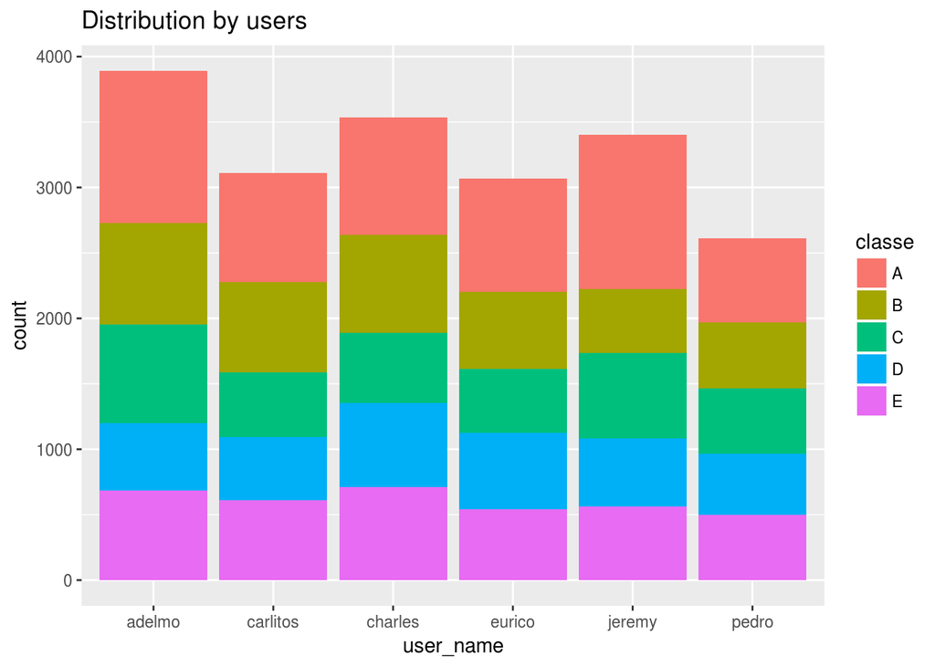

```r
ggplot(train.in, aes(user_name)) +
  geom_bar(aes(fill = classe)) +
  ggtitle("Distribution by users")
```

There is some correlation between a sample numerical variables and `classe` variable, but it is hard to conclude something strong based on the scatterplots that underline only univarite interactions between variables.

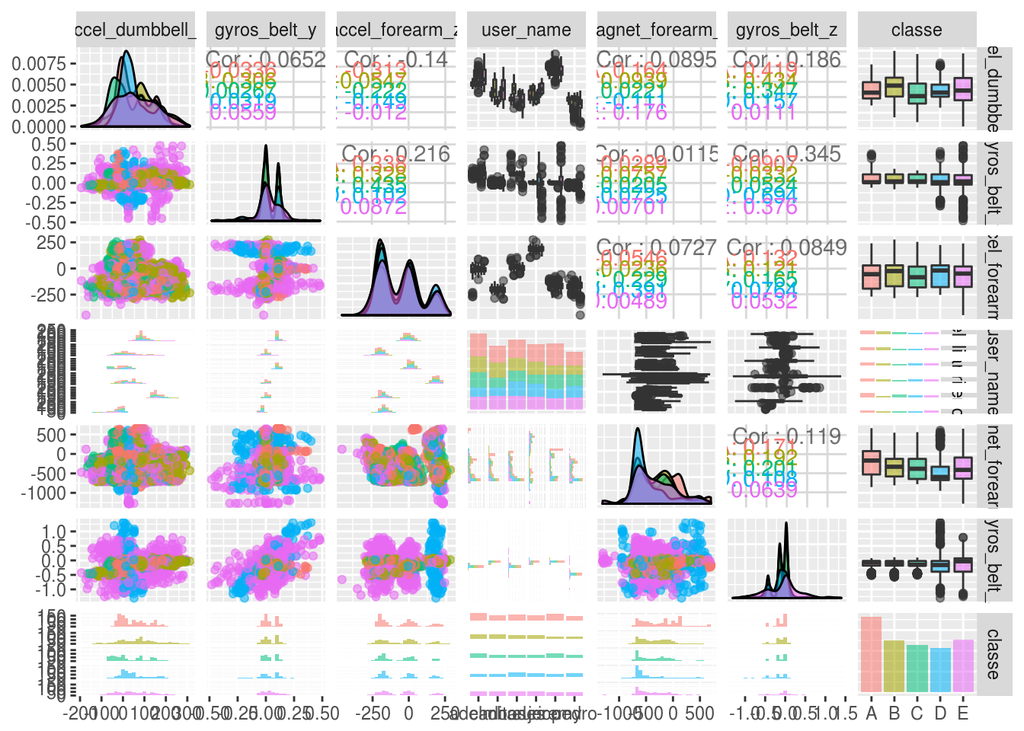

```r
library(GGally, quietly = TRUE, warn.conflicts = FALSE)

set.seed(20170805)
columns.to.select <- train.in %>% select(-classe) %>% names
columns.to.plot <- sample(columns.to.select, 12)

to.plot.one <- train.in %>% select(columns.to.plot[1:6], classe) %>% sample_frac(0.2)
to.plot.two <- train.in %>% select(columns.to.plot[7:12], classe) %>% sample_frac(0.2)

g1 <- ggpairs(to.plot.one, aes(colour = classe, alpha = 0.4))
g2 <- ggpairs(to.plot.two, aes(colour = classe, alpha = 0.4))

suppressMessages(print(g1))
```

```r
suppressMessages(print(g2))
```

[figure not shown]

## Statistical modeling

In many cases it is easier to work with encoded factor variables, so all the predictors are numerical. Here is used one-hot-encoder to achive the goal. Thus instead of one factor variable `user_name` six numerical variables are created consisting of only two values `0` and `1`.

```r
encoded.factors.train <- model.matrix(~ user_name + 0, data=train.in)
encoded.factors.test <- model.matrix(~ user_name + 0, data=test.in)
train.in <- data.frame(select(train.in, -user_name), encoded.factors.train)
test.in <- data.frame(select(test.in, -user_name), encoded.factors.test)
```

In order to ease computations target variable `classe` is reindexed from `0` to `4` where `0` corresponds to `A`, `1` to `B` and so on. For the purpose of testing the input data are splitted into train and test sets. The train set includes `16680` observations while the test set only `2942`.

```r
train.in <- train.in %>% mutate(classe = as.numeric(classe) - 1)

inTrain <- createDataPartition(train.in$classe, p = 0.85)[[1]]

train = train.in[inTrain, ]
test = train.in[-inTrain, ]

c(length(train$classe), length(test$classe))
```

```
## [1] 16680  2942
```

In order to free RAM memory for model fitting unused variables are removed and garbage collector is explicitly called.

```r
rm(
  train.in,
  to.plot.one,
  to.plot.two,
  encoded.factors.test,
  encoded.factors.train,
  columns.to.plot,
  columns.to.select,
  fit,
  is.numeric.columns,
  nas.ratios,
  unique.ratios,
  inTrain)
gc()
```

```
##           used (Mb) gc trigger  (Mb) max used  (Mb)
## Ncells 1616335 86.4    2637877 140.9  2637877 140.9
## Vcells 2734060 20.9   12924062  98.7 16154858 123.3
```

The first model is `Random Forest`. It performs very well with defaults parameters obtaining `99.9%` of accuracy on test data therefore there is no need for hyper-parameter optimization via validation or crossvalidation.

```r
fit.rf <- suppressMessages(
  train(I(as.factor(classe)) ~ ., data = train, method = "rf", trControl = trainControl(method = "none")))
predictions.rf <- predict(fit.rf, test)
m <- confusionMatrix(data = predictions.rf, reference = test$classe)
m$table
```

```
##           Reference
## Prediction   0   1   2   3   4
##          0 830   0   0   0   0
##          1   0 575   1   0   0
##          2   0   0 513   1   0
##          3   0   0   0 481   0
##          4   0   0   0   0 541
```

```r
m$overall
```

```
##       Accuracy          Kappa  AccuracyLower  AccuracyUpper   AccuracyNull
##      0.9993202      0.9991406      0.9975465      0.9999177      0.2821210
## AccuracyPValue  McnemarPValue
##      0.0000000            NaN
```

The second model is `Gradient Boosting Trees`. The perfromance of that model with default parameters is relatively low compared to `Random Forests`. The accuracy only achives `81.8%` which is not acceptable.

```r
fit.gbm <- suppressMessages(suppressWarnings(
  train(I(as.factor(classe)) ~ ., data = train, method = "gbm", trControl = trainControl(method = "none"))))
predictions.gbm <- predict(fit.gbm, test)
m <- confusionMatrix(data = predictions.gbm, reference = test$classe)
```

```r
m$table
```

```
##           Reference
## Prediction   0   1   2   3   4
##          0 760  81  20  36   8
##          1   7 391  27  17  37
##          2   1  75 454  39  37
##          3  45  28  12 368  24
##          4  17   0   1  22 435
```

```r
m$overall
```

```
##       Accuracy          Kappa  AccuracyLower  AccuracyUpper   AccuracyNull
##   8.184908e-01   7.699953e-01   8.040786e-01   8.322666e-01   2.821210e-01
## AccuracyPValue  McnemarPValue
##   0.000000e+00   2.347830e-36
```

The typicall way to increase accuracy is hyper-parameter optimization employing cross-validation at every step to estimate out-of-sample error rate. Here the simpliest grid search is used supported by `2`-fold cross-validation to leverage execution time. The size of the search grid is only `8` combinations. This achives accuracy of `99.9%` which is a significant inprovement compared to previos model.

```r
control <- trainControl(method = "cv", number = 2, search = "grid")
grid <- expand.grid(interaction.depth = c(3, 5), shrinkage = c(.01, .1), n.minobsinnode = c(10, 20), n.trees = 200)

fit.gbm <- suppressWarnings(train(I(as.factor(classe)) ~ ., data = train, method = "gbm", trControl = control, tuneGrid = grid, metric='Accuracy'))
predictions.gbm <- predict(fit.gbm, test)
m <- confusionMatrix(data = predictions.gbm, reference = test$classe)
```

```r
m$table
```

```
##           Reference
## Prediction   0   1   2   3   4
##          0 830   1   0   0   0
##          1   0 574   1   0   0
##          2   0   0 513   1   0
##          3   0   0   0 481   1
##          4   0   0   0   0 540
```

```r
m$overall
```

```
##       Accuracy          Kappa  AccuracyLower  AccuracyUpper   AccuracyNull
##      0.9986404      0.9982811      0.9965225      0.9996294      0.2821210
## AccuracyPValue  McnemarPValue
##      0.0000000            NaN
```

Another powerfull technique for statistical modeling is `Extreme Gradient Boosting`. This method is quite fast in terms of fitting time and normally provides good accuracy with default settings. The resulting accuracy hits the level of `98.6%` which is quite good having only `30` iterations and thereafter the least fitting time.

```r
classes <- length(unique(train$classe))

params <- list(
  "objective" = "multi:softprob",
  "eval_metric" = "mlogloss",
  "num_class" = classes)

D <- xgb.DMatrix(as.matrix(train %>% select(-classe)), label = train$classe)
fit.xgb <- xgboost(data = D, params = params, nrounds = 30)

D <- xgb.DMatrix(as.matrix(test %>% select(-classe)))
predictions.xgb.raw <- predict(fit.xgb, D)
predictions.xgb <- matrix(
  predictions.xgb.raw,
  nrow = classes,
  ncol=length(predictions.xgb.raw) / classes) %>%
  t() %>%
  apply(1, function(x) { which.max(x) - 1 })

m <- confusionMatrix(data = predictions.xgb, reference = test$classe)
```

```r
m$table
```

```
##           Reference
## Prediction   0   1   2   3   4
##          0 823   3   0   5   1
##          1   2 564   4   0   2
##          2   3   8 507   8   0
##          3   2   0   3 469   1
##          4   0   0   0   0 537
```

```r
m$overall
```

```
##       Accuracy          Kappa  AccuracyLower  AccuracyUpper   AccuracyNull
##      0.9857240      0.9819511      0.9807515      0.9896923      0.2821210
## AccuracyPValue  McnemarPValue
##      0.0000000            NaN
```

## Prediction

The agreement ratio of the models accounts for `98.6%` which gives the curtain hopes that out-of-sample error will be at least at that level.

```r
predictions <- data.frame("rf" = predictions.rf, "gbm" = predictions.gbm, "xgb" = predictions.xgb)

x <- predictions %>% mutate(agree = rf == gbm & gbm == xgb)
table(x$agree) / length(x$agree)
```

```
##
##     FALSE      TRUE
## 0.0139361 0.9860639
```

Now it is time to make predictions for the oservations with unknown target variable `classe`. The agreement accuracy is `100%` which is a good indicator. Submitting results to the grader gives accuracy of `100%`.

```r
predictions.rf <- suppressMessages(predict(fit.rf, test.in))
predictions.gbm <- predict(fit.gbm, test.in)
D <- xgb.DMatrix(as.matrix(test.in))
predictions.xgb.raw <- predict(fit.xgb, D)
predictions.xgb <- matrix(
  predictions.xgb.raw,
  nrow = classes,
  ncol=length(predictions.xgb.raw) / classes) %>%
  t() %>%
  apply(1, function(x) { which.max(x) - 1 })

predictions <- data.frame("rf" = predictions.rf, "gbm" = predictions.gbm, "xgb" = predictions.xgb)

## Predictions do agree on 100% cases which gives 100% accuracy after submission.
x <- predictions %>% mutate(agree = rf == gbm & gbm == xgb)
table(x$agree) / length(x$agree)
```

```
##
## TRUE
##    1
```

```r
table(x$rf)
```

```
##
## 0 1 2 3 4
## 7 8 1 1 3
```

# Results

The analysis resulted in the robust three-model ansemble where the accuracy of every model on unseen dataset is greater than `98.6%`. The concepts of hyper-parameter-tuning and cross-validation helped to improve accuracy of `Gradient Boosting Trees` from only `81.8%` to about `99.9%` accuracy.